© Bản quyền thuộc về Quantopian Inc.  
© Bản quyền sửa đổi thuộc về AI Cafe¹  
Giấy phép [Creative Commons Attribution 4.0](https://creativecommons.org/licenses/by/4.0/legalcode).  
[Khuyến cáo](https://aicafe.one/khuyen-cao/)

# Biểu diễn (trực quan hoá) dữ liệu

By Evgenia "Jenny" Nitishinskaya, Maxwell Margenot, and Delaney Granizo-Mackenzie

Edited by AI Cafe¹

Việc biểu diễn dữ liệu một cách trực quan có thể cực kỳ hữu ích cho việc tìm hiểu cách mà dữ liệu hoạt động và thấy được cấu trúc hoặc sai sót tiềm ẩn. Cần phải thận trọng, vì con người rất giỏi trong việc chỉ nhìn thấy bằng chứng xác nhận niềm tin của mình, và dữ liệu trực quan rất dễ dàng cho điều đó. Đồ thị rất tốt để sử dụng khi hình thành một giả thuyết, nhưng không nên được sử dụng để kiểm tra một giả thuyết.

Chúng ta sẽ xem qua một số loại đồ thị phổ biến ở đây.

```python
# Import our libraries

# This is for numerical processing
import numpy as np
# This is the library most commonly used for plotting in Python.
# Notice how we import it 'as' plt, this enables us to type plt
# rather than the full string every time.
import matplotlib.pyplot as plt
```

## Lấy dữ liệu

Việc đầu tiên là chúng ta cần có dữ liệu để biểu diễn. Ở đây chúng ta sẽ lấy dữ liệu từ nguồn miễn phí (CafeF) thông qua hàm `get_prices` thư viện:

```python
# Cài thư viện lấy dữ liệu miễn phí
!curl -fsSLO https://raw.githubusercontent.com/algo-stocks/data/master/data.py
```

### Cấu trúc Dữ liệu

Biết được cấu trúc của dữ liệu là rất quan trọng. Thông thường, bạn sẽ phải làm rất nhiều công việc để định hình dữ liệu của mình thành dạng mà bạn cần cho việc kiểm tra.

Trong trường hợp dưới đây, dữ liệu sẽ được trả về dưới dạng đối tượng pandas dataframe. Các hàng là các dấu thời gian, và các cột là các mã chứng khoán FPT và VCB.

```python
from data import get_prices

start = '2024-01-01'
end = '2025-01-01'

data = get_prices('FPT', 'VCB', start_date=start, end_date=end)
data.head()
```

| date | FPT | VCB |
| --- | --- | --- |
| 2024-01-02 | 82.2478 | 55.8532 |
| 2024-01-03 | 82.5908 | 56.5221 |
| 2024-01-04 | 83.3627 | 57.4585 |
| 2024-01-05 | 83.5342 | 57.6592 |
| 2024-01-08 | 83.4485 | 58.0605 |

Việc lập chỉ mục vào dataframe 2D sẽ cho chúng ta một đối tượng chuỗi 1D. Chỉ mục cho chuỗi là các dấu thời gian, giá trị tại chỉ mục là một mức giá. Tương tự như một mảng, nhưng thay vì chỉ mục là số nguyên, thì ở đây là thời gian.

```python
data['FPT'].head()
```

| date | FPT |
| --- | --- |
| 2024-01-02 | 82.2478 |
| 2024-01-03 | 82.5908 |
| 2024-01-04 | 83.3627 |
| 2024-01-05 | 83.5342 |
| 2024-01-08 | 83.4485 |

**dtype:** float64

## Biểu đồ Histogram

Biểu đồ histogram là một hình ảnh thể hiện tần suất của các giá trị dữ liệu khác nhau. Bằng cách hiển thị phân bố tần suất thông qua các thanh, nó cho phép chúng ta nhanh chóng thấy được hầu hết các quan sát được nhóm lại ở đâu. Chiều cao của mỗi thanh đại diện cho số lượng quan sát nằm trong mỗi khoảng. Bạn có thể nghĩ về biểu đồ histogram như một Hàm Mật độ Xác suất (PDF) thực nghiệm và rời rạc.

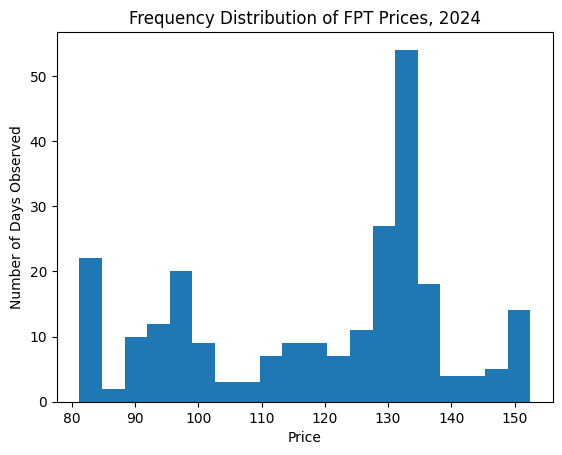

```python
# Plot a histogram using 20 bins
plt.hist(data['FPT'], bins=20)
plt.xlabel('Price')
plt.ylabel('Number of Days Observed')
plt.title('Frequency Distribution of FPT Prices, 2024');
```

### Biểu Đồ Phân Phối Lợi Nhuận

Trong lĩnh vực tài chính, hiếm khi chúng ta xem xét phân phối của giá cả. Nguyên nhân là do giá cả không ổn định và thường xuyên biến động. Thay vào đó, chúng ta sẽ sử dụng lợi nhuận hàng ngày. Hãy cùng thử nghiệm điều đó ngay bây giờ.

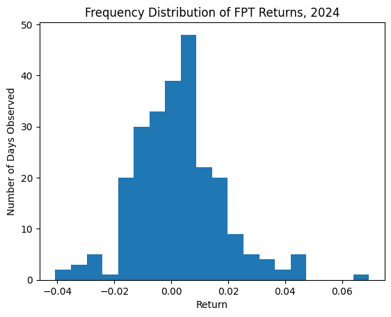

```python
# Remove the first element because percent change from nothing to something is NaN
R = data['FPT'].pct_change()[1:]

# Plot a histogram using 20 bins
plt.hist(R, bins=20)
plt.xlabel('Return')
plt.ylabel('Number of Days Observed')
plt.title('Frequency Distribution of FPT Returns, 2024');
```

Biểu đồ trên cho thấy, ví dụ, rằng lợi nhuận hàng ngày của FPT cao hơn 0,06 vào chưa đến 5 ngày trong năm 2024. Lưu ý rằng chúng ta hoàn toàn loại bỏ các ngày tương ứng với những lợi nhuận này.

QUAN TRỌNG: Cũng lưu ý rằng điều này không có nghĩa là các lợi nhuận trong tương lai sẽ có cùng phân phối.

### Biểu đồ Tích lũy (CDF ước lượng rời rạc)

Một cách khác để hiển thị dữ liệu là sử dụng hàm phân phối tích lũy, trong đó chiều cao của một cột biểu thị số lượng quan sát nằm trong cột đó hoặc trong một trong các cột trước đó. Biểu đồ này luôn luôn không giảm vì bạn không thể có số lượng quan sát âm. Sự lựa chọn biểu đồ phụ thuộc vào thông tin mà bạn quan tâm.

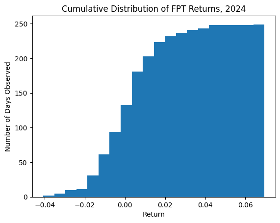

```python
# Remove the first element because percent change from nothing to something is NaN
R = data['FPT'].pct_change()[1:]

# Plot a histogram using 20 bins
plt.hist(R, bins=20, cumulative=True)
plt.xlabel('Return')
plt.ylabel('Number of Days Observed')
plt.title('Cumulative Distribution of FPT Returns, 2024');
```

## Biểu đồ phân tán (Scatter plot)

Biểu đồ phân tán rất hữu ích để trực quan hóa mối quan hệ giữa hai tập dữ liệu. Chúng ta sử dụng hai tập dữ liệu có sự tương ứng nào đó, chẳng hạn như ngày mà phép đo được thực hiện. Mỗi điểm trên biểu đồ đại diện cho hai giá trị tương ứng từ hai tập dữ liệu. Tuy nhiên, chúng ta không vẽ ngày mà các phép đo được thực hiện.

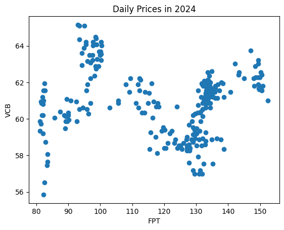

```python
plt.scatter(data['FPT'], data['VCB'])
plt.xlabel('FPT')
plt.ylabel('VCB')
plt.title('Daily Prices in 2024');
```

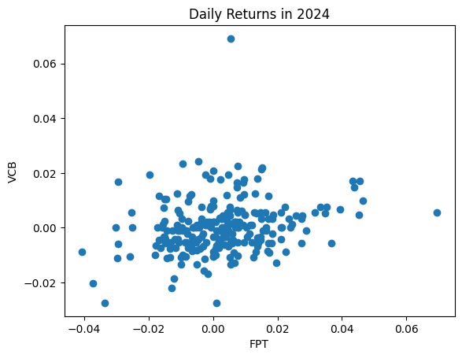

```python
R_FPT = data['FPT'].pct_change()[1:]
R_VCB = data['VCB'].pct_change()[1:]

plt.scatter(R_FPT, R_VCB)
plt.xlabel('FPT')
plt.ylabel('VCB')
plt.title('Daily Returns in 2024');
```

## Biểu đồ đường

Biểu đồ đường có thể được sử dụng khi chúng ta muốn theo dõi sự phát triển của giá trị y khi giá trị x thay đổi. Ví dụ, khi chúng ta vẽ giá cổ phiếu, việc hiển thị nó dưới dạng biểu đồ đường thay vì chỉ vẽ các điểm dữ liệu sẽ giúp dễ dàng theo dõi giá theo thời gian hơn. Điều này nhất thiết liên quan đến việc "kết nối các điểm" giữa các điểm dữ liệu, điều này có thể che giấu những thay đổi đã xảy ra giữa thời điểm chúng ta thực hiện các phép đo.

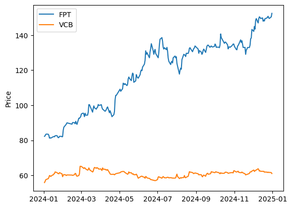

```python
plt.plot(data['FPT'])
plt.plot(data['VCB'])
plt.ylabel('Price')
plt.legend(['FPT', 'VCB']);
```

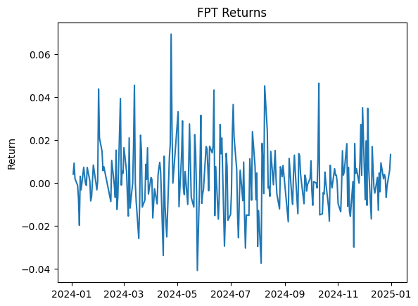

```python
# Remove the first element because percent change from nothing to something is NaN
R = data['FPT'].pct_change()[1:]

plt.plot(R)
plt.ylabel('Return')
plt.title('FPT Returns');
```

## Đừng Bao Giờ Giả Định "Các Điều Kiện là Không Đổi"

Một lần nữa, khi sử dụng đồ thị để trực quan hóa dữ liệu, đừng giả định rằng bạn có thể kiểm tra một giả thuyết chỉ bằng cách nhìn vào đồ thị. Cũng đừng giả định rằng vì một phân phối hoặc xu hướng từng đúng, nên nó vẫn còn đúng. Nói chung, cần có sự xác thực tinh vi và cẩn thận hơn nhiều để kiểm tra xem các mô hình có đúng hay không. Đồ thị chủ yếu hữu ích khi bạn ban đầu quyết định cách mà các mô hình của bạn nên hoạt động.

*Lưu ý: Tài liệu này mang tính chất chia sẻ kiến thức khoa học dữ liệu. Các mã chứng khoán xuất hiện trong tài liệu chỉ mang tính chất minh hoạ, không khuyến nghị đầu tư. Chúng tôi không chịu trách nhiệm trước mọi rủi ro nào do sử dụng tài liệu này.*